# Protocol scRNA-seq - Part III: Clustering

Lena Böhringer

```r
library(dplyr)
library(Seurat)
library(presto)
```

```r
library(ggplot2)
```

### Load data

```r
ple5 <- readRDS("srt_02_ple5.rds")
```

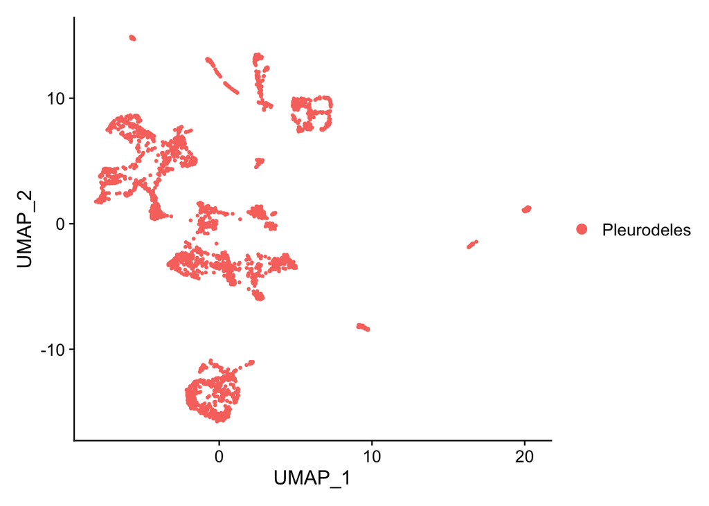

```r
DimPlot(ple5, label=F, reduction = "umap") #specify were data comes from (UMAP or PCA or tSNE)
```

(*Elbow plot already generated in part II*)

# Clustering

scRNA-seq data is very complex. To describe the heterogeneity found in the tissue in a readable way and to summarize the data, we can cluster the cells based on their gene expression. When we have our clusters we can determine what cell type the cluster probably represents by looking at marker genes. However, since there several parameters by which we can change the outcome of the clustering we can never say that the way we clustered is correct or true. It is an iterative approach and probably introduced some subjective bias.

## Finding Neighbors

Before we can cluster the cells, we need to find the nearest neighbors. “k” determines how many neighbor connections are “built”.

```r
ple5 <- FindNeighbors(ple5, reduction = "pca", dims = 1:30, k.param = 20)
```

## Find Clusters

Now the algorithm tries to put the cells in a cluster in a way that maximizes internal connections between neighbors but minimizes external connections. With resolution we can change how many and big the clusters are.

```r
ple5 <- FindClusters(ple5, resolution = c(0.1))
```

```
## Modularity Optimizer version 1.3.0 by Ludo Waltman and Nees Jan van Eck
##
## Number of nodes: 2520
## Number of edges: 68470
##
## Running Louvain algorithm...
## Maximum modularity in 10 random starts: 0.9715
## Number of communities: 10
## Elapsed time: 0 seconds
```

The higher the resolution the more and smaller the clusters. We start with low resolution and increase later.

## Visualize Clusters

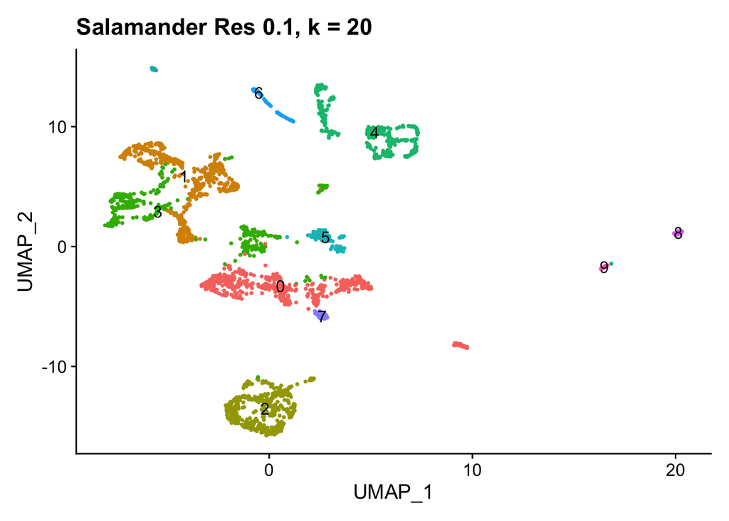

```r
ple5 <- SetIdent(ple5, value = "RNA_snn_res.0.1")

DimPlot(ple5, reduction = "umap", label = T) + NoLegend()  + ggtitle("Salamander Res 0.1, k = 20")
```

### Decrease the k parameter

**k = 10**

```r
ple5 <- FindNeighbors(ple5, k.param = 10, reduction = "pca", dims = 1:30)
ple5 <- FindClusters(ple5, resolution = c(0.1))
```

[output not shown]

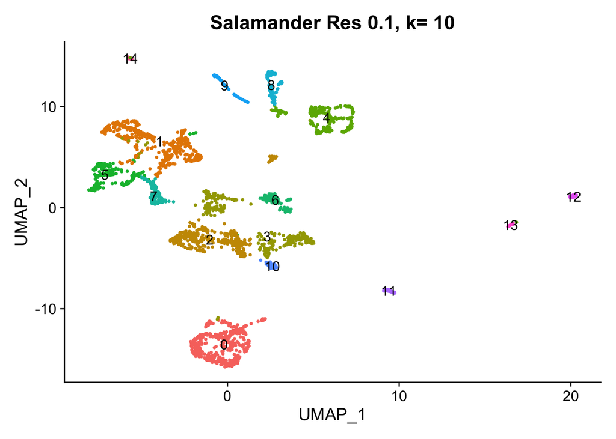

```r
DimPlot(ple5, group.by = "RNA_snn_res.0.1", label = T)  + NoLegend() + ggtitle("Salamander Res 0.1, k= 10")
```

**k = 8**

```r
ple5 <- FindNeighbors(ple5, k.param = 8, reduction = "pca", dims = 1:30)
ple5 <- FindClusters(ple5, resolution = c(0.1))
```

```
## Modularity Optimizer version 1.3.0 by Ludo Waltman and Nees Jan van Eck
##
## Number of nodes: 2520
## Number of edges: 38325
##
## Running Louvain algorithm...
## Maximum modularity in 10 random starts: 0.9722
## Number of communities: 13
## Elapsed time: 0 seconds
```

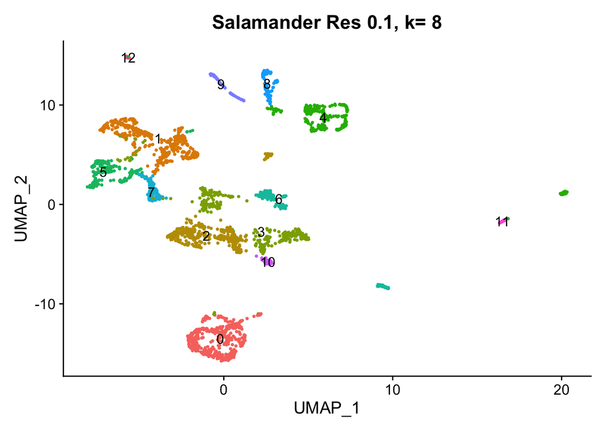

```r
DimPlot(ple5, group.by = "RNA_snn_res.0.1", label = T) + NoLegend() + ggtitle("Salamander Res 0.1, k= 8")
```

I will continue with k = 8

### compare different clustering resolutions

We compare different clustering resolutions to find out which could be the best one. This is an iterative and subjective process, but need to be optimized for each dataset.

```r
ple5 <- FindClusters(ple5, resolution = c(0.1, 0.3, 0.5, 1, 2, 3))
```

```
## Modularity Optimizer version 1.3.0 by Ludo Waltman and Nees Jan van Eck
##
## Number of nodes: 2520
## Number of edges: 38325
##
## Running Louvain algorithm...
## Maximum modularity in 10 random starts: 0.9722
## Number of communities: 13
## Elapsed time: 0 seconds
## Modularity Optimizer version 1.3.0 by Ludo Waltman and Nees Jan van Eck
##
## Number of nodes: 2520
## Number of edges: 38325
##
## Running Louvain algorithm...
## Maximum modularity in 10 random starts: 0.9525
## Number of communities: 18
## Elapsed time: 0 seconds
## Modularity Optimizer version 1.3.0 by Ludo Waltman and Nees Jan van Eck
##
## Number of nodes: 2520
## Number of edges: 38325
##
## Running Louvain algorithm...
## Maximum modularity in 10 random starts: 0.9384
## Number of communities: 21
## Elapsed time: 0 seconds
## Modularity Optimizer version 1.3.0 by Ludo Waltman and Nees Jan van Eck
##
## Number of nodes: 2520
## Number of edges: 38325
##
## Running Louvain algorithm...
## Maximum modularity in 10 random starts: 0.9100
## Number of communities: 32
## Elapsed time: 0 seconds
## Modularity Optimizer version 1.3.0 by Ludo Waltman and Nees Jan van Eck
##
## Number of nodes: 2520
## Number of edges: 38325
##
## Running Louvain algorithm...
## Maximum modularity in 10 random starts: 0.8724
## Number of communities: 43
## Elapsed time: 0 seconds
## Modularity Optimizer version 1.3.0 by Ludo Waltman and Nees Jan van Eck
##
## Number of nodes: 2520
## Number of edges: 38325
##
## Running Louvain algorithm...
## Maximum modularity in 10 random starts: 0.8421
## Number of communities: 57
## Elapsed time: 0 seconds
```

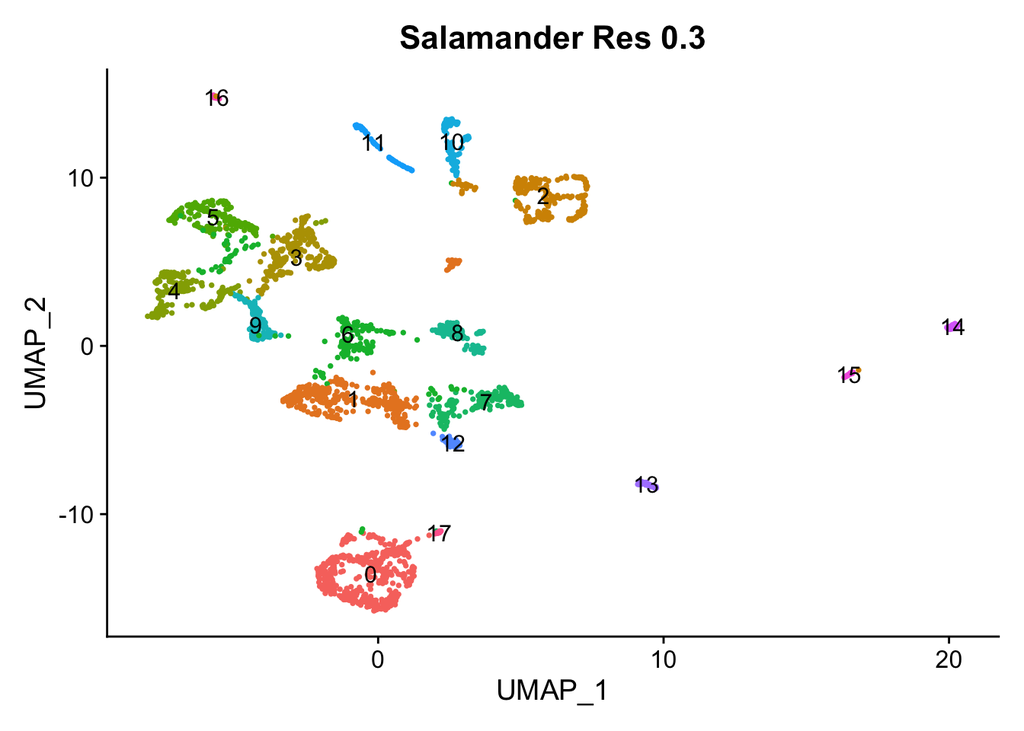

```r
DimPlot(ple5, group.by = "RNA_snn_res.0.3", reduction = "umap", label = T)+ NoLegend() + ggtitle("Salamander Res 0.3")
```

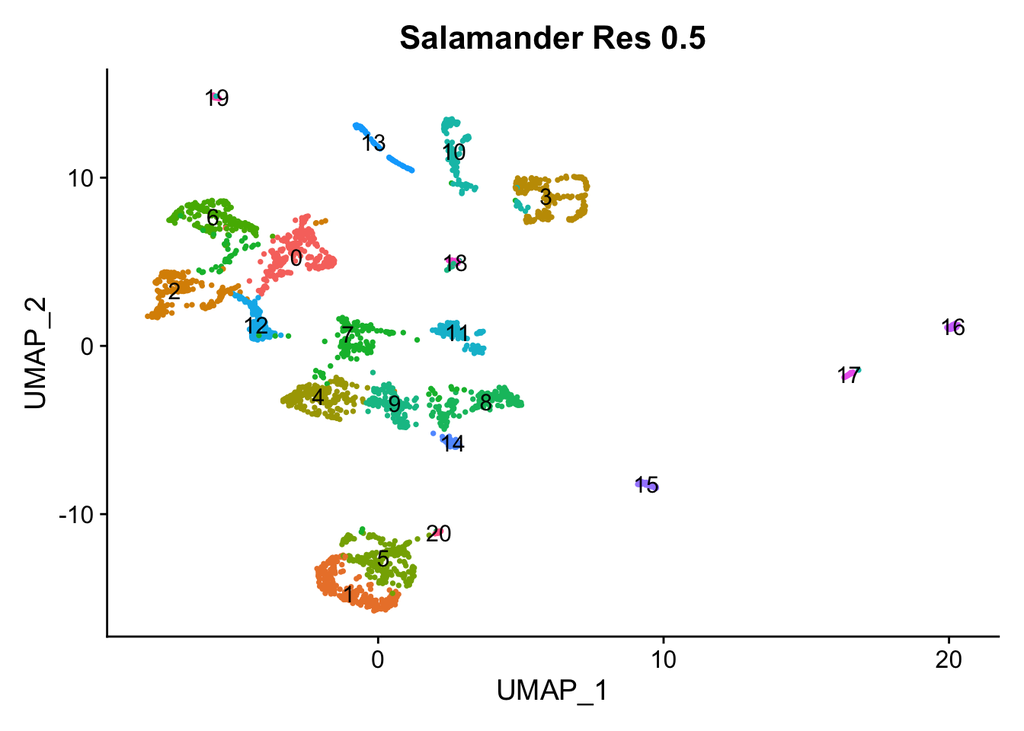

```r
DimPlot(ple5, group.by = "RNA_snn_res.0.5", reduction = "umap", label = T) + NoLegend() + ggtitle("Salamander Res 0.5")
```

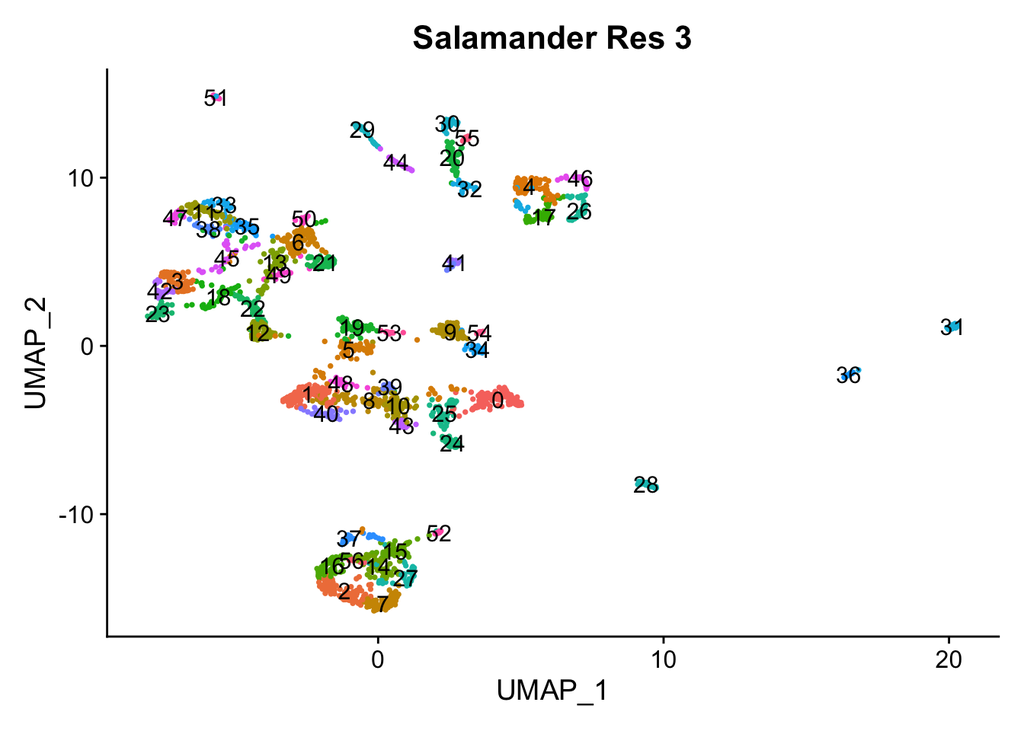

```r
DimPlot(ple5, group.by = "RNA_snn_res.3", reduction = "umap", label = T) + NoLegend() + ggtitle("Salamander Res 3")
```

With resolution = 3 we generate many very small clusters. This might lead to over-clustering, where we will have many clusters that only contain a small cell number.

To see how many cells are in the clusters we use the table function.

```r
table(ple5$RNA_snn_res.0.1)
```

```
##
##   0   1   2   3   4   5   6   7   8   9  10  11  12
## 430 416 388 308 273 206 147 106  97  61  42  30  16
```

```r
table(ple5$RNA_snn_res.0.3)
```

```
##
##   0   1   2   3   4   5   6   7   8   9  10  11  12  13  14  15  16  17
## 415 380 237 224 206 176 171 161 110 106  97  61  42  37  36  30  16  15
```

```r
table(ple5$RNA_snn_res.0.5)
```

```
##
##   0   1   2   3   4   5   6   7   8   9  10  11  12  13  14  15  16  17  18  19
## 224 220 206 202 198 195 176 171 161 158 132 110 106  61  42  37  36  30  24  16
##  20
##  15
```

```r
table(ple5$RNA_snn_res.3)
```

```
##
##   0   1   2   3   4   5   6   7   8   9  10  11  12  13  14  15  16  17  18  19
## 119 117  91  82  81  81  78  78  73  70  69  64  60  60  60  55  55  55  54  54
##  20  21  22  23  24  25  26  27  28  29  30  31  32  33  34  35  36  37  38  39
##  51  50  46  46  42  42  42  37  37  37  36  36  36  32  30  30  30  30  28  27
##  40  41  42  43  44  45  46  47  48  49  50  51  52  53  54  55  56
##  26  24  24  24  24  24  23  22  21  20  16  16  15  11  10  10   9
```

This shows that in a resolution of 3 the clusters contain only very few cells.

In my opinion Res0.3 looks best as here we have a nice separation of the clusters, whereas in res0.5 it seems like some parts are over-clustered.

# Identifying and plotting marker genes

```r
ple5 <- SetIdent(ple5, value = "RNA_snn_res.0.3")
```

## Plotting known markers

If we know marker genes of certain cell types we can look at them in a Featureplot and see, which clusters express these markers. This can give us a first idea which clusters might be which cell types. Additionally this can tell us whether our resolution is good or needs to be improved.

### Glu neurons - Pallium cells

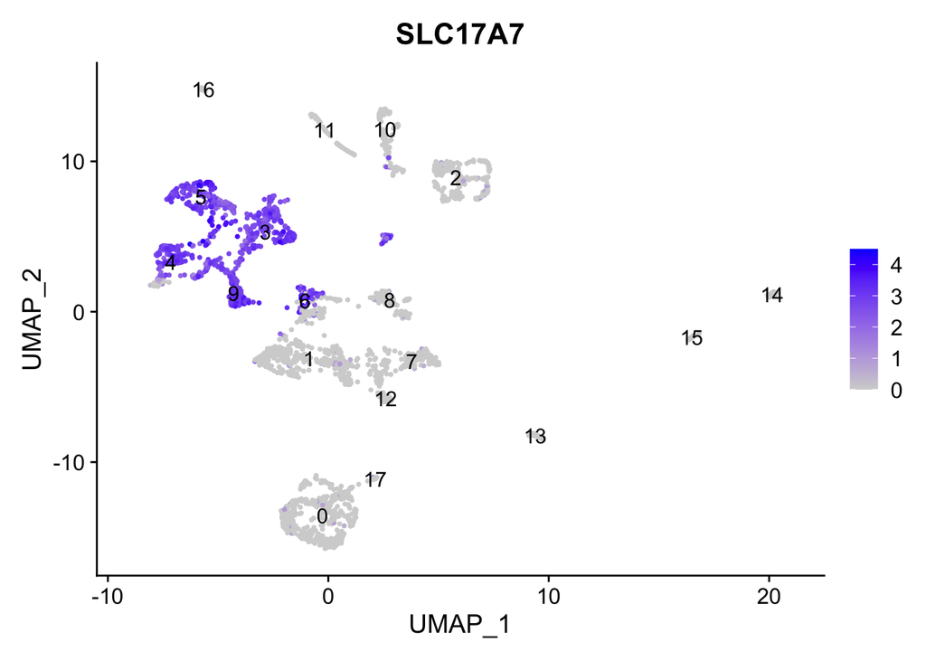

```r
FeaturePlot(ple5, features="SLC17A7", label=T)
```

### Glu neurons - Amygdala cells

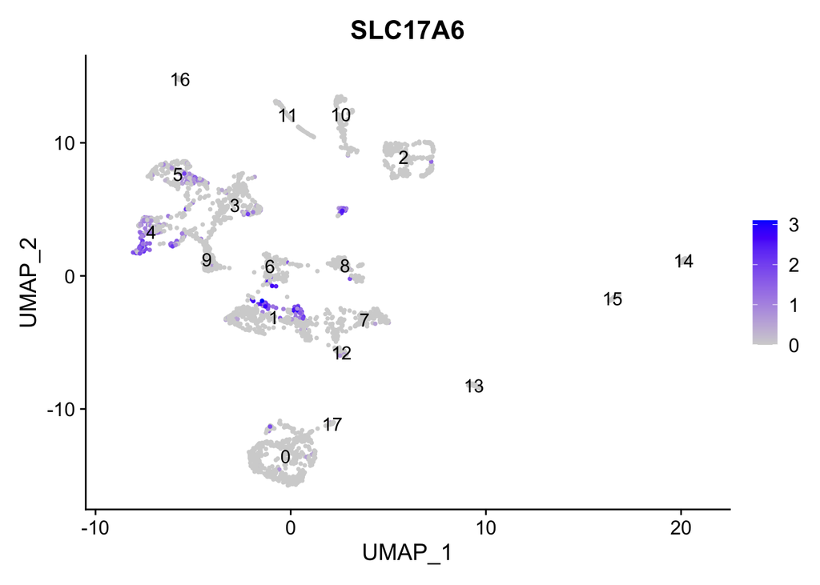

```r
FeaturePlot(ple5, features="SLC17A6", label=T)
```

### GABA neurons

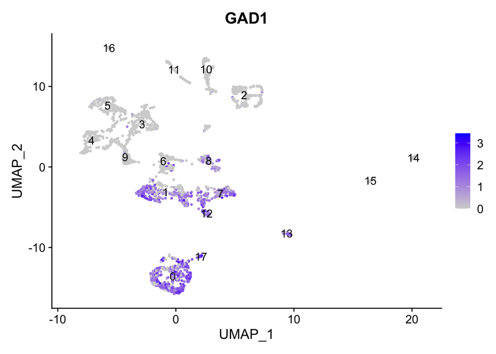

```r
FeaturePlot(ple5, features="GAD1", label=T)
```

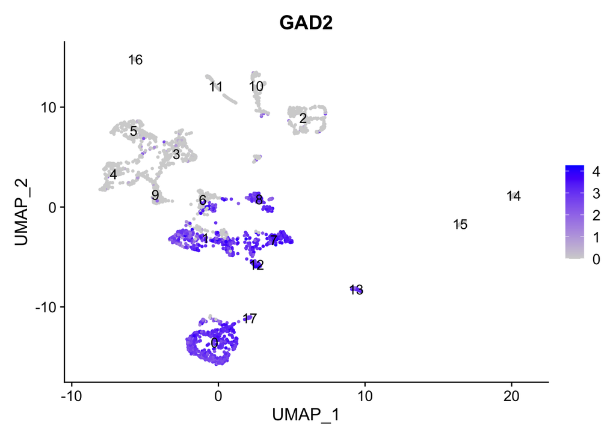

```r
FeaturePlot(ple5, features="GAD2", label=T)
```

We can already assume the different clusters for glutaminergic and GABAergic cells. By looking at more markers we can examine the clusters in more detail and determine their identity.

## Find all marker genes distinguishing clusters

The function FindAllMarkers finds genes that the different cluster express in an unbiased way (above we have a gene and look which clusters express this gene).

```r
ple5 <- SetIdent(ple5,value = "RNA_snn_res.0.3")
ple5.markers <- FindAllMarkers(ple5, min.pct = 0.25) # the marker is expressed in at least 25% of the cells in the cluster
head(ple5.markers)
```

|  | p_val | avg_log2FC | pct.1 | pct.2 | p_val_adj | cluster | gene |
| --- | --- | --- | --- | --- | --- | --- | --- |
| SHISA8 | 0.000000e+00 | 2.363229 | 0.889 | 0.032 | 0.000000e+00 | 0 | SHISA8 |
| RYR1 | 1.621493e-273 | 1.940350 | 0.855 | 0.113 | 2.124642e-269 | 0 | RYR1 |
| PPFIBP2 | 7.548401e-264 | 1.521087 | 0.834 | 0.095 | 9.890669e-260 | 0 | PPFIBP2 |
| SP9 | 1.143367e-242 | 1.934048 | 0.906 | 0.161 | 1.498153e-238 | 0 | SP9 |
| TSHZ1 | 2.083770e-242 | 1.930657 | 0.882 | 0.148 | 2.730364e-238 | 0 | TSHZ1 |
| MEIS3 | 1.303236e-240 | 1.702300 | 0.863 | 0.133 | 1.707631e-236 | 0 | MEIS3 |

We can now for example look at cluster 0 and plot the top 5 genes expressed in this cluster.

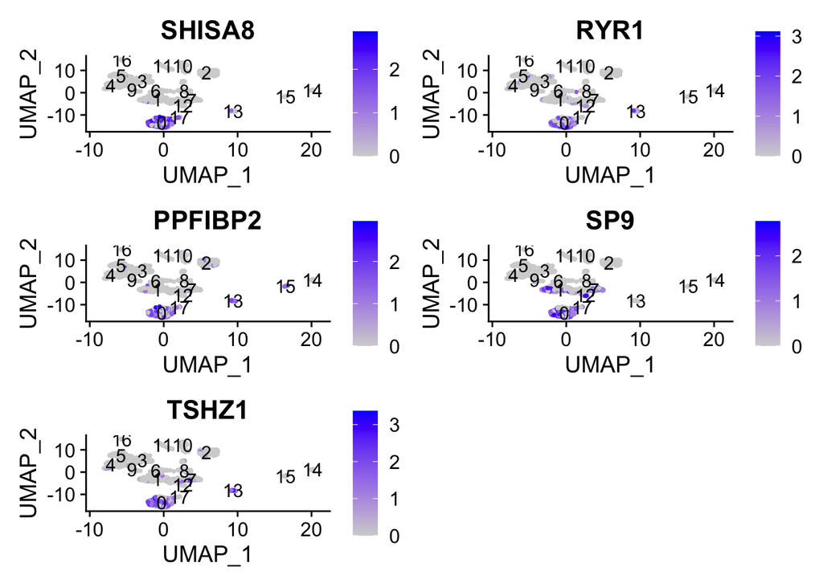

```r
cluster0.markers <- ple5.markers %>%
  dplyr::filter(cluster == 0) %>%
  dplyr::arrange(p_val) #order by p-value

cluster0_top_5 <- cluster0.markers$gene[1:5]

FeaturePlot(object = ple5, feature = cluster0_top_5, label = T)
```

When we want to compare two clusters that look similar, we can look at the markers that are most differentialy expressed by the following function:

```r
ple5 <- SetIdent(ple5,value = "RNA_snn_res.0.3")

cluster0.17.markers <- FindMarkers(ple5, ident.1 = 0, ident.2 = 17, min.pct = 0.25)

head(cluster0.17.markers, n = 30)
```

|  | p_val | avg_log2FC | pct.1 | pct.2 | p_val_adj |
| --- | --- | --- | --- | --- | --- |
| CRTAC1 | 3.865646e-78 | -2.2869072 | 0.005 | 0.933 | 5.065156e-74 |
| ADAMTS2 | 1.294082e-77 | -2.0070160 | 0.005 | 0.933 | 1.695635e-73 |
| PRKCD | 1.321355e-76 | -1.8309628 | 0.002 | 0.867 | 1.731372e-72 |
| RELN | 2.468761e-63 | -2.7480484 | 0.014 | 0.933 | 3.234818e-59 |
| STXBP5L | 6.215440e-63 | -1.7854630 | 0.010 | 0.867 | 8.144091e-59 |
| TEAD4 | 2.378201e-60 | -1.0934427 | 0.007 | 0.800 | 3.116157e-56 |
| CPLX3 | 3.800427e-57 | -3.2929919 | 0.027 | 1.000 | 4.979699e-53 |
| ADAMTS5 | 3.800427e-57 | -3.6714557 | 0.027 | 1.000 | 4.979699e-53 |
| SLC29A1 | 4.352107e-57 | -0.8685145 | 0.000 | 0.600 | 5.702566e-53 |
| LRRC75A | 1.121653e-56 | -0.9625209 | 0.014 | 0.867 | 1.469701e-52 |

[output cut: 20 more lines]

We can take a more detailed look in a violin plot and see the distribution of the top 10 genes that are most different in the two clusters.

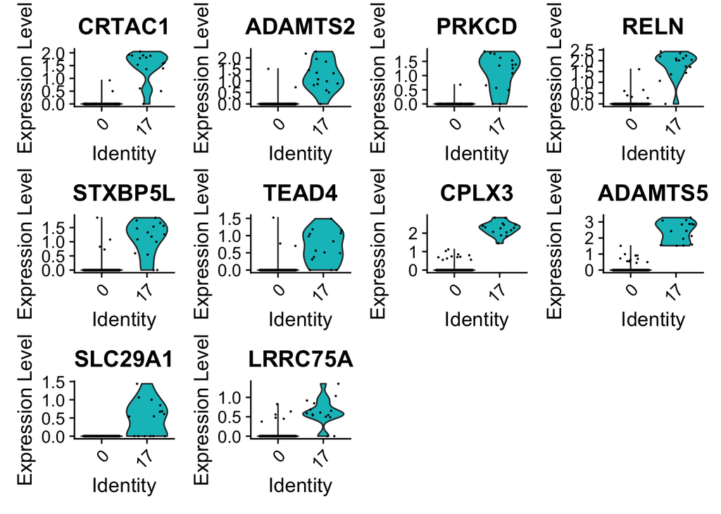

```r
cluster0.17.marker.names <- rownames(cluster0.17.markers)[1:10]

VlnPlot(ple5, features = cluster0.17.marker.names, idents=c(0,17))
```

```r
saveRDS(ple5, "srt_03_ple5.rds")
```